# Educação em Direitos Humanos no Campo · Trabalho, Dignidade e Justiça Rural

Sociologia Rural

Prof. Dr. Luiz Diego Vidal Santos

## Abertura Visão Geral da Aula

Roteiro da aula Tópicos principais

- 1 Direitos Humanos — Fundamentos
- 2 Direitos Trabalhistas no Campo
- 3 Trabalho Análogo à Escravidão
- 4 Conflitos Agrários e Violência
- 5 Extensão Rural e Educação em Direitos

Objetivo central Trabalho, dignidade e justiça rural

Compreender os direitos humanos aplicados ao meio rural brasileiro, analisando violações estruturais, marcos legais de proteção e o papel do engenheiro agrônomo na promoção da dignidade e justiça no campo.

DUDH · CF/1988 Art. 149 CP · NR-31 PNEDH · PNATER · OIT

Articulando marcos constitucionais, saúde do trabalhador e responsabilidade ética na ATER.

# Fundamentos e Direitos Trabalhistas no Campo

## Direitos Direitos Humanos: Fundamentos e Marcos Legais

ONU (1948) · CF/1988 Fundamentos e princípios

Os direitos humanos são garantias fundamentais **inerentes a toda pessoa**, reconhecidos pela Declaração Universal dos Direitos Humanos (ONU, 1948) e incorporados à Constituição Federal de 1988.

**Princípios estruturantes:**

- Universalidade
- Indivisibilidade
- Interdependência
- Inalienabilidade

Ordenamento jurídico brasileiro Marcos Legais no Brasil

- **CF/1988 — Art. 5º** (direitos fundamentais)
- **CF/1988 — Art. 6º** (direitos sociais)
- **CF/1988 — Art. 186** (função social da propriedade rural)
- **Estatuto da Terra** (Lei 4.504/64)
- **Estatuto do Trabalhador Rural** (Lei 5.889/73)
- **PNDH-3** — Decreto 7.037/2009

## Vulnerabilidade Direitos Humanos e o Meio Rural

No campo brasileiro, os direitos humanos apresentam violações de natureza **estrutural** e **histórica**, distribuídas em seis dimensões de vulnerabilidade.

01 · Acesso à terra Concentração fundiária

Impede que milhões de famílias acessem terra para produção e moradia.

02 · Trabalho digno Precarização laboral

Condições precárias, informalidade, sazonalidade e baixa remuneração.

03 · Segurança alimentar Paradoxo rural

Paradoxo de quem produz alimento e passa fome no campo.

04 · Educação Escolas rurais

Infraestrutura deficiente e currículo descontextualizado da realidade agrária.

05 · Saúde Atenção básica

Cobertura precária de serviços de saúde em municípios rurais.

06 · Participação política Representação

Sub-representação das populações rurais nas instâncias decisórias.

## Trabalho Estatuto do Trabalhador Rural (Lei 5.889/73)

Lei 5.889/73 · CF/1988, Art. 7º Equiparação de direitos urbanos e rurais

A legislação garante ao trabalhador rural os mesmos direitos do trabalhador urbano:

- Salário mínimo
- Jornada máxima de **8 horas diárias / 44 semanais**
- Repouso semanal remunerado
- Férias anuais + 1/3 constitucional
- 13º salário
- FGTS e aposentadoria
- Proteção à maternidade e paternidade

IBGE (2017) Fosso entre norma e realidade

A informalidade no trabalho rural ultrapassa **60%** nos estados do Nordeste, significando que a maioria dos trabalhadores não tem acesso efetivo a esses direitos.

A formalização do vínculo rural é condição básica para a proteção previdenciária e trabalhista no campo.

# Trabalho Escravo Contemporâneo e Conflitos Agrários

## Violações Trabalho Análogo à Escravidão (Art. 149, CP)

Art. 149 do Código Penal Definição Legal

O trabalho análogo à escravidão se configura por:

- **Trabalho forçado** — cerceamento de liberdade
- **Jornada exaustiva** — degradação física extrema
- **Condições degradantes** — alojamento, alimentação e higiene
- **Servidão por dívida** — retenção por adiantamentos ou cobranças abusivas

MTE/SIT · Fiscalização Móvel Dados acumulados (1995–2023)

O Grupo Especial de Fiscalização Móvel resgatou:

- **59.564 trabalhadores** em condição análoga à escravidão entre 1995 e 2023
- **Setores mais frequentes no campo:** pecuária, cana-de-açúcar, soja, café, carvão vegetal
- **Estados com maior incidência:** Pará, Maranhão, Mato Grosso, Minas Gerais

A **“Lista Suja”** do trabalho escravo (Cadastro de Empregadores) é instrumento de **transparência e accountability**.

## Indicadores Resgates de Trabalho Análogo à Escravidão (MTE/SIT)

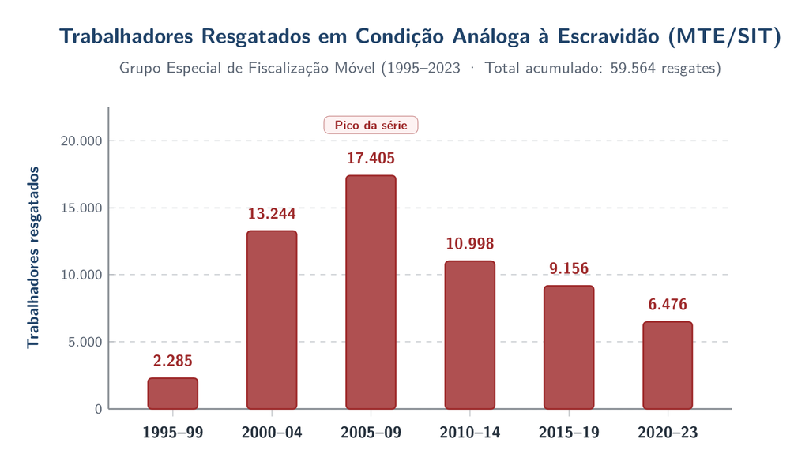

Evolução quinquenal dos trabalhadores resgatados pelo Grupo Especial de Fiscalização Móvel entre 1995 e 2023 (MTE/SIT).

Trabalhadores Resgatados em Condição Análoga à Escravidão (MTE/SIT, 1995–2023) Grupo Especial de Fiscalização Móvel · Total acumulado: 59.564 resgates · Pico da série em 2005–2009 (17.405)

A persistência dos resgates ao longo de quase três décadas evidencia o caráter estrutural da superexploração em cadeias agropecuárias e extrativas.

## Caso Trabalho Escravo — Caso José Pereira vs. Brasil

Sul do Pará · 1989 A violação

Em 1989, o trabalhador rural **José Pereira**, então com 17 anos, foi submetido a trabalho forçado em uma fazenda no sul do Pará. Ao tentar fugir, foi baleado, perdendo a visão de um olho e o uso de uma mão.

CIDH · 2003 Responsabilização do Estado

O caso foi apresentado à **Comissão Interamericana de Direitos Humanos (CIDH)**, que responsabilizou o Estado brasileiro por **omissão** na proteção dos trabalhadores rurais.

**Consequência:** o Brasil firmou acordo reconhecendo a responsabilidade e se comprometeu a intensificar ações de combate ao trabalho escravo no campo — marco na construção da política nacional de enfrentamento.

## Indicadores Conflitos por Terra no Campo Brasileiro (CPT)

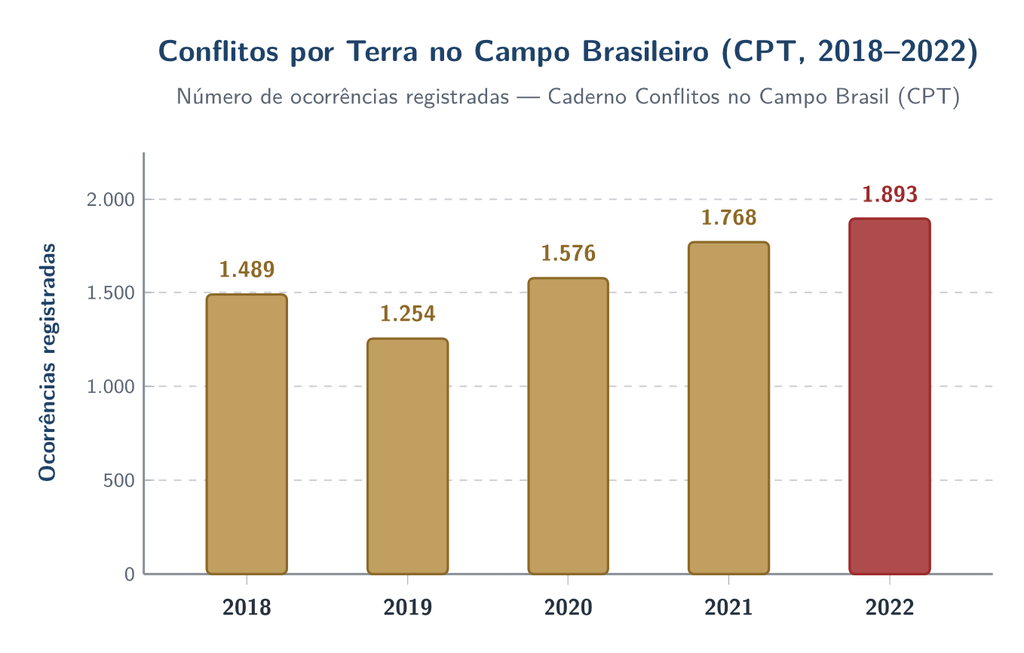

Número de ocorrências de conflitos por terra registradas no campo brasileiro entre 2018 e 2022 segundo a Comissão Pastoral da Terra (CPT).

Conflitos por Terra no Campo Brasileiro (CPT, 2018–2022) Fonte: Comissão Pastoral da Terra — Caderno Conflitos no Campo Brasil (crescimento contínuo de 2019 a 2022, atingindo 1.893 ocorrências)

Os registros da **CPT** revelam escalada contínua das disputas fundiárias e territoriais no campo brasileiro no período recente.

## Conflitos Conflitos Agrários e Violência no Campo

CPT · Dados de 2022 Violência documentada

A Comissão Pastoral da Terra documenta anualmente os conflitos no campo brasileiro:

- **1.893 conflitos por terra** registrados em 2022
- **47 assassinatos** de lideranças e trabalhadores rurais em 2022
- Aumento de ameaças e intimidações contra defensores de direitos no campo
- Invasões de territórios indígenas e quilombolas

Múltiplas frentes de disputa Tipologia dos Conflitos

- **Fundiários:** disputa pela posse e titulação de terras
- **Trabalhistas:** condições de trabalho e remuneração
- **Ambientais:** desmatamento e contaminação por agrotóxicos
- **Hídricos:** acesso à água, barragens e irrigação
- **Étnicos:** demarcação de terras indígenas e quilombolas

*“O campo brasileiro é, historicamente, o território onde os direitos humanos são mais frequentemente violados”* (Martins, 2000).

# Saúde, Função Social da Terra e Convenções da OIT

## Saúde Agrotóxicos e Direito à Saúde

O Brasil é o **maior consumidor de agrotóxicos do mundo desde 2008**, e a exposição ocupacional afeta diretamente os trabalhadores rurais.

Exposição ocupacional e ambiental Impactos na saúde

- Intoxicações agudas (pele, olhos, sistema respiratório)
- Doenças crônicas (câncer, disfunções endócrinas, danos neurológicos)
- Contaminação de águas e alimentos nas comunidades adjacentes
- Suicídio entre agricultores expostos a organofosforados

NR-31 · Responsabilidade técnica Marco legal e papel do agrônomo

A **NR-31** (Norma Regulamentadora de Segurança e Saúde no Trabalho na Agricultura) estabelece obrigações para empregadores quanto ao uso seguro de agrotóxicos, incluindo **EPIs, treinamento e exames periódicos**.

O engenheiro agrônomo, ao emitir **receituário agronômico**, tem responsabilidade direta na proteção da saúde do trabalhador.

## Constituição Direito à Terra e Função Social (Art. 186, CF/88)

A Constituição Federal de 1988, **Art. 186**, define que a propriedade rural cumpre sua **função social** quando atende simultaneamente quatro requisitos:

01 · Produção Uso racional

Aproveitamento racional e adequado do imóvel rural.

02 · Meio ambiente Preservação

Utilização adequada dos recursos naturais e preservação ambiental.

03 · Trabalho Leis trabalhistas

Observância das disposições que regulam as relações de trabalho.

04 · Bem-estar Equilíbrio social

Exploração que favoreça proprietários e trabalhadores.

CF/1988, Art. 184 Desapropriação

O descumprimento da função social é, constitucionalmente, motivo para **desapropriação** para fins de reforma agrária.

Fernandes (2001) · Sauer (2010) Disputa política

Na prática, a aplicação desse dispositivo é **limitada e politicamente disputada**, exigindo mobilização social e fiscalização efetiva.

## Normas OIT Convenções da OIT para o Meio Rural

A Organização Internacional do Trabalho (**OIT**) possui convenções específicas para a proteção do trabalhador rural:

| Convenção | Tema | Ratificação Brasil |
| --- | --- | --- |
| **C029** (1930) | Trabalho Forçado | 1957 |
| **C105** (1957) | Abolição do Trabalho Forçado | 1965 |
| **C141** (1975) | Organizações de Trabalhadores Rurais | 1994 |
| **C155** (1981) | Segurança e Saúde dos Trabalhadores | 1992 |
| **C169** (1989) | Povos Indígenas e Tribais | 2002 |
| **C184** (2001) | Segurança e Saúde na Agricultura | Não ratificada |

A **não ratificação da Convenção 184**, específica sobre segurança na agricultura, é uma lacuna significativa na proteção dos trabalhadores rurais brasileiros.

# Educação em Direitos Humanos, ATER e Síntese

## Educação Educação em Direitos Humanos na Agronomia

PNEDH (2006) O que é EDH?

A Educação em Direitos Humanos (EDH) é um processo de **formação continuada** que visa:

- Construir cultura de respeito à dignidade humana
- Desenvolver capacidade de identificar e combater violações
- Promover cidadania ativa e participativa
- Fortalecer mecanismos de proteção

Atuação cotidiana no campo EDH na Formação do Agrônomo

Onde direitos são violados cotidianamente, a formação deve incluir:

- Reconhecimento de situações de trabalho degradante
- **Receituário agronômico** como instrumento de **proteção** (não apenas técnico)
- Mediação de conflitos em assentamentos e comunidades
- Noções de legislação trabalhista e ambiental
- Ética profissional na relação com trabalhadores rurais

## ATER Extensão Rural e Direitos Humanos (PNATER)

A **PNATER (Lei 12.188/2010)** incorpora princípios de direitos humanos ao definir que a extensão rural deve promover **inclusão social**, **equidade de gênero** e **respeito à diversidade**.

**1.** Inclusão de temas de direitos nas atividades de formação (**Escolas de Campo**).

**2.** Articulação com órgãos de fiscalização (**MTE, MPT**) para denúncia de irregularidades.

**3.** Assessoria jurídica a assentamentos e comunidades tradicionais.

**4.** Promoção de **segurança do trabalho** como componente da ATER.

**5.** Formação de agentes comunitários de saúde e direitos.

*“O extensionista que ignora as violações de direitos no campo não é apenas omisso — é **cúmplice**”* (Martins, 2000).

A assistência técnica comprometida com direitos humanos transforma a rotina de campo em espaço de prevenção, denúncia e cidadania.

## Síntese Conclusão

Formação indissociável Dignidade em jogo no campo

A educação em direitos humanos é componente indissociável da formação do engenheiro agrônomo. O profissional que atua no campo lida cotidianamente com situações onde a dignidade humana está em jogo — no receituário agronômico (saúde do trabalhador), na assistência técnica (condições de trabalho) e na mediação de conflitos (acesso à terra).

Atuação ética e propositiva O agrônomo-extensionista

Conhecer os marcos legais, reconhecer as violações e atuar de forma ética e propositiva são competências que distinguem o **agrônomo-extensionista** do mero técnico de produção.

Garantir direitos trabalhistas, saúde ocupacional e função social da terra é parte integrante da engenharia agronômica democrática.

## Referências Referências Bibliográficas

Marcos legais e internacionais Legislação e convenções

- Brasil. *Constituição Federal* (1988) — Art. 5º, 6º, 7º, 184, 186.
- Brasil. *Lei 5.889/73* — Estatuto do Trabalhador Rural.
- Brasil. *Lei 12.188/2010* — PNATER.
- Brasil. *Decreto 7.037/2009* — PNDH-3.
- OIT. *Convenções fundamentais do trabalho* (2024).

Dados, relatórios e estudos Literatura e monitoramento

- CPT. *Conflitos no Campo Brasil 2022* (2023).
- Fernandes, B. M. *Questão agrária, pesquisa e MST* (2001).
- Martins, J. S. *Reforma agrária: o impossível diálogo* (2000).
- MTE/SIT. *Trabalho escravo no Brasil em retrospectiva* (2023).
- Sauer, S. *Terra e modernidade* (2010).

Obrigado!

Luiz Diego Vidal Santos

Universidade Estadual de Feira de Santana (UEFS)